# Prueba t de Student

Derek Corcoran  
"04/04, 2018"

### En este práctico

- Probaremos el paquete `learnr`
- Pruebas de t de para una muestra
- Pruebas de t para dos muestras
- Supuestos y alternativas a la prueba **t de student**

### Prueba de una muestra

- \( H_0 \) media de una población = una media teórica
- Ejemplo erupciones del géiser *Old Faithful*
- Guardaparque dice que géiser erupta cada 1 hora
- Base de datos `faithful`

### Funcion t.test()

```r
data("faithful")
t.test(x = faithful$waiting, mu = 60, alternative = "two.sided")
```

```
    One Sample t-test

data:  faithful$waiting
t = 13.22, df = 271, p-value < 2.2e-16
alternative hypothesis: true mean is not equal to 60
95 percent confidence interval:
 69.27418 72.51994
sample estimates:
mean of x
 70.89706
```

### Ejercicio 1

- Base de datos `airquality`
- Partículas de ozono cada día de Mayo a Septiembre de 1973 entre 13:00 y 15:00
- Disminuir a la mitad los pasajes del metro de Nueva York los meses que en promedio tengan sobre 55 ppb.
- Comprobar estadisticamente que meses tienen promedios sobre 55.
- ¿Si se tienen todos los días por que hay que hacer prueba estadística?
- Generen una tabla resumen con las medias y desviaciones estandar de ozono para cada mes

### Resumen por meses

```r
library(tidyverse)
SummMonth <- airquality %>% group_by(Month) %>% summarize(Mean = mean(Ozone, na.rm = TRUE), SD = sd(Ozone, na.rm = TRUE))
```

| Month | Mean | SD |
| --- | --- | --- |
| 5 | 23.61538 | 22.22445 |
| 6 | 29.44444 | 18.20790 |
| 7 | 59.11538 | 31.63584 |
| 8 | 59.96154 | 39.68121 |
| 9 | 31.44828 | 24.14182 |

### Prueba de t

```r
AirJuly <- airquality %>% filter(Month == 7)
AirAug <- airquality %>% filter(Month == 8)
t.test(AirJuly$Ozone, mu = 55, alternative = "greater")
```

```
    One Sample t-test

data:  AirJuly$Ozone
t = 0.66331, df = 25, p-value = 0.2566
alternative hypothesis: true mean is greater than 55
95 percent confidence interval:
 48.51757      Inf
sample estimates:
mean of x
 59.11538
```

```r
t.test(AirAug$Ozone, mu = 55, alternative = "greater")
```

```
    One Sample t-test

data:  AirAug$Ozone
t = 0.63756, df = 25, p-value = 0.2648
alternative hypothesis: true mean is greater than 55
95 percent confidence interval:
 46.66857      Inf
sample estimates:
mean of x
 59.96154
```

### Prueba de t

¿En que meses se debiera aplicar el descuento?

### Pruebas de 2 muestras

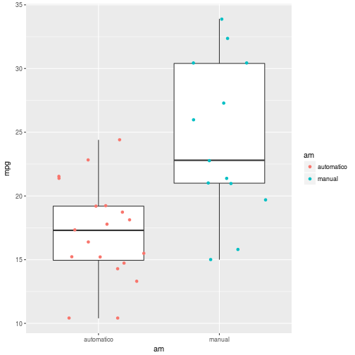

- En base de datos `mtcars` columna *am* designa si un vehiculo es automático (0) o manual (1)
- Para prueba t de dos muestras debemos agregar el argumento `var.equal`
- Usamos nuevamente simbolo ~ explicado por

```r
t.test(mpg ~ am, data = mtcars, var.equal =TRUE)
```

```
    Two Sample t-test

data:  mpg by am
t = -4.1061, df = 30, p-value = 0.000285
alternative hypothesis: true difference in means is not equal to 0
95 percent confidence interval:
 -10.84837  -3.64151
sample estimates:
mean in group 0 mean in group 1
       17.14737        24.39231
```

### Ejercicio 2

- Base de datos `BeerDark` en webcursos o en el siguiente [link](https://archive.org/download/BeerDark/BeerDark.csv).
- **Estilo:** Separa las cervezas entre Porters y Stouts
- **Grado_Alcoholico:** El grado alcoholico de las cervezas
- **Amargor:** Valor IBU (International Bittering Units), a mayor valor más amarga la cerveza
- **Color:** A mayor valor más oscura la cerveza.
- Determinar si las cervezas Porter y Stouts son distintas en grado alcoholico, amargor y/o color.

### Ejercicio 2

```r
BeerDark <- read_csv("https://archive.org/download/BeerDark/BeerDark.csv")
t.test(Amargor ~ Estilo, var.equal =TRUE, data = BeerDark)
```

```
    Two Sample t-test

data:  Amargor by Estilo
t = -21.233, df = 6409, p-value < 2.2e-16
alternative hypothesis: true difference in means is not equal to 0
95 percent confidence interval:
 -16.70647 -13.88231
sample estimates:
mean in group Porter  mean in group Stout
            37.80220             53.09659
```

### Supuestos de prueba t

- **Independencia de las observaciones**
- **Distribución normal de los datos en cada grupo**
- Homogeneidad de varianza

### Normalidad

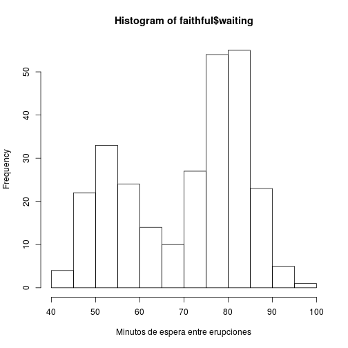

```r
hist(faithful$waiting, xlab = "Minutos de espera entre erupciones")
```

### Normalidad

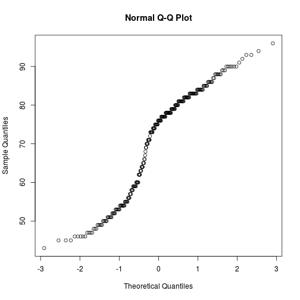

```r
qqnorm(faithful$waiting)
```

### Normalidad

```r
shapiro.test(faithful$waiting)
```

```
    Shapiro-Wilk normality test

data:  faithful$waiting
W = 0.92215, p-value = 1.015e-10
```

### Alternativa Mann-Whitney

- Igual que `t.test` pero `wilcox.test`

```r
data("faithful")
wilcox.test(x = faithful$waiting, mu = 60, alternative = "two.sided")
```

```
    Wilcoxon signed rank test with continuity correction

data:  faithful$waiting
V = 31048, p-value < 2.2e-16
alternative hypothesis: true location is not equal to 60
```

### Prueba dos muestras dividir en clases

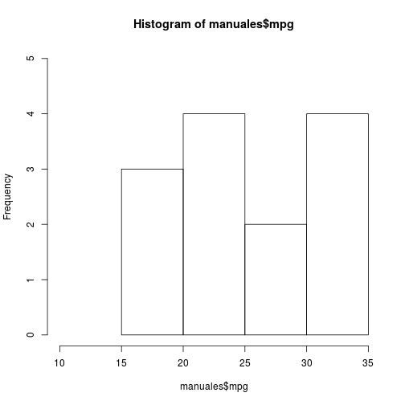

```r
manuales <- mtcars %>% filter(am == 1)
hist(manuales$mpg, xlim = c(10,35), ylim = c(0,5))
```

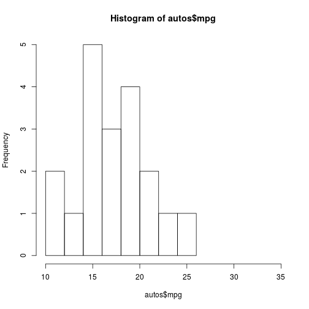

```r
autos <- mtcars %>% filter(am == 0)
hist(autos$mpg, xlim = c(10,35), ylim = c(0,5))
```

### Prueba dos muestras dividir en clases

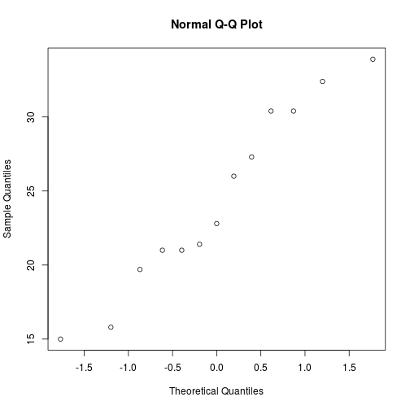

```r
qqnorm(manuales$mpg)
```

### Homogeneidad de varianza

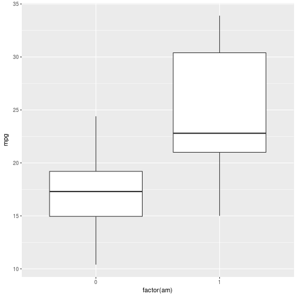

```r
ggplot(mtcars, aes(x = factor(am), y = mpg)) + geom_boxplot()
```

```r
bartlett.test(mpg ~ am, data = mtcars)
```

```
    Bartlett test of homogeneity of variances

data:  mpg by am
Bartlett's K-squared = 3.2259, df = 1, p-value = 0.07248
```

### Mann-Whitney 2 muestras

```r
wilcox.test(mpg ~ am, data = mtcars)
```

```
    Wilcoxon rank sum test with continuity correction

data:  mpg by am
W = 42, p-value = 0.001871
alternative hypothesis: true location shift is not equal to 0
```

### Ejercicio 3

- Evalue basado en histograma, qqplot y test de shapiro si se debe reevaluar la hipótesis para los meses de julio y agosto y si es necesario haga una nueva prueba
- Evalúe si es necesario revaluar la hipotesis de que el amargor es distinto entre ambos estilos de cerveza y si es necesario haga una nueva prueba